# IODS course project

Janne Piiroinen

# About the project

### Welcome

to my humble landing page and to the Introduction to *Open Data Science*-course together with me and the others!  
Data science is growing in importance and on this course we will be learning related practical skills and of course, have fun when doing it!

[Here is a link to my GitHub repository](https://github.com/BreezewindX/IODS-project)

# Analysis part of the R-exercise 2

This week I’ve worked with wrangling, tidying and interpreting questionnaire data and learned how to plot and test linear regression models. Seems like attitude is a main factor affecting the test scores among the variables included in the study. The week has been a good refresher of the previous statistics courses and I have learned more about using Rmarkdown for presenting the results from R.

## Introduction to the data *learning2014*

The data in question is a survey of students’ study skills SATS and their attitudes towards statistics ASSIST gathered 3.12.2014 - 10.1.2015. Students’ approach to study skills were divided into deep, strategic and surface categories. Here are the descriptions from a presentation by Kimmo Vehkalahti:.

**Surface approach:** memorizing without understanding, with a serious lack of personal engagement in the learning process.  
**Deep approach:** intention to maximize understanding, with a true commitment to learning.  
**Strategic approach:** the ways students organize their studying (apply any strategy that maximizes the chance of achieving the highest possible grades).

*Points* variable states the points received in a statistics exam. Those who had 0 points (which means that the participant did not attend the exam) were filtered out from the data.

## Summary of the data

```r
learning2014 <- read.csv("https://raw.githubusercontent.com/BreezewindX/IODS-project/master/data/learning2014.csv")
summary(learning2014)
```

```
##  gender       age           attitude          deep            stra
##  F:110   Min.   :17.00   Min.   :1.400   Min.   :1.583   Min.   :1.250
##  M: 56   1st Qu.:21.00   1st Qu.:2.600   1st Qu.:3.333   1st Qu.:2.625
##          Median :22.00   Median :3.200   Median :3.667   Median :3.188
##          Mean   :25.51   Mean   :3.143   Mean   :3.680   Mean   :3.121
##          3rd Qu.:27.00   3rd Qu.:3.700   3rd Qu.:4.083   3rd Qu.:3.625
##          Max.   :55.00   Max.   :5.000   Max.   :4.917   Max.   :5.000
##       surf           points
##  Min.   :1.583   Min.   : 7.00
##  1st Qu.:2.417   1st Qu.:19.00
##  Median :2.833   Median :23.00
##  Mean   :2.787   Mean   :22.72
##  3rd Qu.:3.167   3rd Qu.:27.75
##  Max.   :4.333   Max.   :33.00
```

The data consists of seven variables and has the query results of 166 persons, which of only 56 were men (maybe a bit small sample size). There was approximately twice the amount of females compared to males among the participants. The age of participants was between 17 and 55 years.

## Scatterplot matrix between the variables

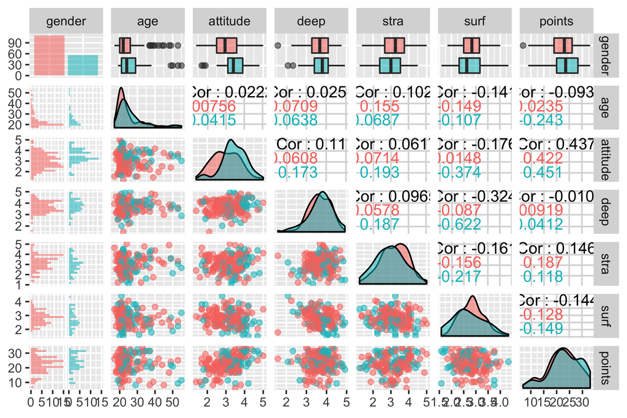

```r
library(GGally)
ggpairs(learning2014, mapping = aes(col = gender, alpha = 0.3), lower = list(combo = wrap("facethist", bins = 20)))
```

From the matrix we can see that the variables that *correlate* positively with points in the exam the most are *attitude* (0.437) and *stra* (0.146). Variable *surf* (-0.144) is negatively correlated. Correlation typically refers to *how close two variables are to having a linear relationship with each other*.

There is not that much correlation between the study skills, largest is -0.324 between ‘deep’ and ‘surf’ (which is notable, but logical as it’s unlikely that a student using surface approach uses also deep approach).

The mean of *attitude* score for men is somewhat higher than for women and in general not that many men scored low in attitude. There seems to be not much difference in the use of deep study skills between genders and women seem to rely more on the strategic study skills.

We’ll choose the following linear model for regression
$$points_i \sim \beta_i+\beta_2attitude_i+\beta_3stra_i+\beta_4surf_i+\epsilon_i$$
Where $\beta_i$ is the intercept and $\epsilon_i$ is the error term.

```r
# create a regression model with multiple explanatory variables
my_model <- lm(points ~ attitude + stra + surf, data = learning2014)

# print out a summary of the model
summary(my_model)
```

```
##
## Call:
## lm(formula = points ~ attitude + stra + surf, data = learning2014)
##
## Residuals:
##      Min       1Q   Median       3Q      Max
## -17.1550  -3.4346   0.5156   3.6401  10.8952
##
## Coefficients:
##             Estimate Std. Error t value Pr(>|t|)
## (Intercept)  11.0171     3.6837   2.991  0.00322 **
## attitude      3.3952     0.5741   5.913 1.93e-08 ***
## stra          0.8531     0.5416   1.575  0.11716
## surf         -0.5861     0.8014  -0.731  0.46563
## ---
## Signif. codes:  0 '***' 0.001 '**' 0.01 '*' 0.05 '.' 0.1 ' ' 1
##
## Residual standard error: 5.296 on 162 degrees of freedom
## Multiple R-squared:  0.2074, Adjusted R-squared:  0.1927
## F-statistic: 14.13 on 3 and 162 DF,  p-value: 3.156e-08
```

According to Multiple R-squared value, predictors jointly explain only 0.21 (21%) of the observed variance on the dependent variable. F-statistic for the regression tells us that we can reject the null hypothesis that all our explanatory variables are zero, so we don’t have to abandon the model at this point.

The positive coeffiecient of 3.40 for variable *attitude* is statistically significant even at 0.001 significance level.

P-values for variables *stra* and *surf* are higher than 0.05, which means we cannot, at the 95% confidence level, reject the null hypothesis that their coefficients are zero (ceteris paribus). Thus they are candidates for discarding.

Let’s test and alternative hypothesis that both *stra* and *surf* are jointly zero, $H_0:\beta_3=\beta_4=0$.

```r
library(car)
ss_results<- linearHypothesis(my_model,  c("stra = 0", "surf = 0"))
print(ss_results)
```

```
## Linear hypothesis test
##
## Hypothesis:
## stra = 0
## surf = 0
##
## Model 1: restricted model
## Model 2: points ~ attitude + stra + surf
##
##   Res.Df    RSS Df Sum of Sq      F Pr(>F)
## 1    164 4641.1
## 2    162 4544.4  2    96.743 1.7244 0.1815
```

We get the P-value of 0.182 (>0.05) which means we cannot reject the joint null hypothesis at 95% confidence level.

Lets now drop these two ‘redundant’ variables. The new regression model is
$$points_i \sim \beta_1 +\beta_2attitude_i+\epsilon_i$$

```r
# create a regression model without redundant variables
new_model <- lm(points ~ attitude, data = learning2014)

# print out a summary of the model
summary(new_model)
```

```
##
## Call:
## lm(formula = points ~ attitude, data = learning2014)
##
## Residuals:
##      Min       1Q   Median       3Q      Max
## -16.9763  -3.2119   0.4339   4.1534  10.6645
##
## Coefficients:
##             Estimate Std. Error t value Pr(>|t|)
## (Intercept)  11.6372     1.8303   6.358 1.95e-09 ***
## attitude      3.5255     0.5674   6.214 4.12e-09 ***
## ---
## Signif. codes:  0 '***' 0.001 '**' 0.01 '*' 0.05 '.' 0.1 ' ' 1
##
## Residual standard error: 5.32 on 164 degrees of freedom
## Multiple R-squared:  0.1906, Adjusted R-squared:  0.1856
## F-statistic: 38.61 on 1 and 164 DF,  p-value: 4.119e-09
```

## Evaluating the assumptions of the model

The assumptions made  
1. errors are normally distributed  
2. errors are not correlated  
3. the errors have constant variance (homoscedasticity)

$$\epsilon\sim N(0,\sigma^2)$$

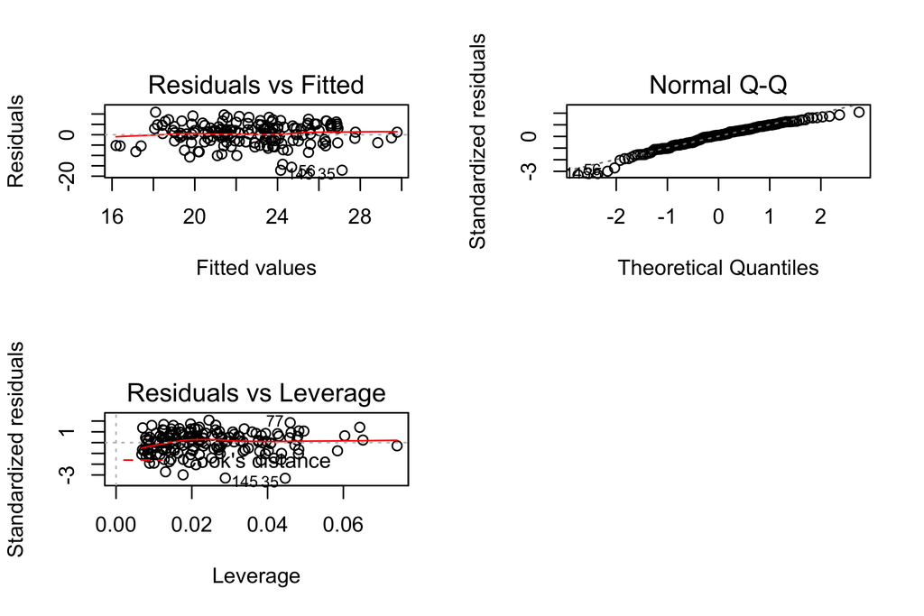

```r
# draw diagnostic plots using the plot() function. Choose the plots 1, 2 and 5
par(mfrow = c(2,2))
plot(my_model, which=c(1,2,5))
```

### Assessing assumptions visually

Looking at the Q-Q-plot, the assumption of normality of the residuals seems reasonable, as most of the points are located on the line, even if some outliers can be seen at the edges.

No obvious pattern emerges in the plotting of residuals vs fitted values (variance seems constant) and none of the observations have big leverage over the whole regression.

Visual inspection implies that these assumptions are met. It’s however a bit hard to say for sure that the variance is constant, so few tests might be in place to confirm this.

### Testing if variance is a constant

We can test for multiplicative heteroscedasticity using Breusch-Pagan test, testing against $H_0$ of no heteroscedasticity.

```r
library(lmtest)
library(dplyr)
new_model %>%
  lmtest::bptest() -> bpresults
print(bpresults)
```

```
##
##  studentized Breusch-Pagan test
##
## data:  .
## BP = 0.0039163, df = 1, p-value = 0.9501
```

We get p-value = 0.95, so cannot reject null hypothesis - we’ve found no evidence against homoscedasticity.

The White test is a generalization of the Breusch-Pagan test and may detect more general forms of heteroscedasticity.

```r
whiteresults <- bptest(new_model, ~ attitude + I(attitude^2), data = learning2014)
print(whiteresults)
```

```
##
##  studentized Breusch-Pagan test
##
## data:  new_model
## BP = 0.088873, df = 2, p-value = 0.9565
```

With the White test we get a p-value of 0.957, which means that we have not found any evidence against the assumptions of our linear regression model.

# Analysis part of the R-exercise 3

## 1 & 2 Preparing the data

The data are from two identical questionaires related to secondary school student alcohol comsumption in Portugal. The data attributes include student grades, demographic, social and school related features) and it was collected by using school reports and questionnaires. Two datasets are provided regarding the performance in two distinct subjects: Mathematics (mat) and Portuguese language (por). You can find more information [here](https://archive.ics.uci.edu/ml/datasets/Student+Performance).

Following adjustments have been made:  
1. The variables not used for joining the two data have been combined by averaging (including the grade variables)  
2. *alc_use* is the average of *Dalc* and *Walc*  
3. *high_use* is TRUE if *alc_use* is higher than 2 and FALSE otherwise

Let’s takea look at the names of the variables in our dataset:

```r
alc <- read.csv("https://raw.githubusercontent.com/BreezewindX/IODS-project/master/data/alc.csv")

colnames(alc)
```

```
##  [1] "school"     "sex"        "age"        "address"    "famsize"
##  [6] "Pstatus"    "Medu"       "Fedu"       "Mjob"       "Fjob"
## [11] "reason"     "nursery"    "internet"   "guardian"   "traveltime"
## [16] "studytime"  "failures"   "schoolsup"  "famsup"     "paid"
## [21] "activities" "higher"     "romantic"   "famrel"     "freetime"
## [26] "goout"      "Dalc"       "Walc"       "health"     "absences"
## [31] "G1"         "G2"         "G3"         "alc_use"    "high_use"
```

## 3 Choosing the variables

I’ll choose *high_use* as dependent variable and *failures*, *absences* and *sex* as explanatory variables.

My intuition is that  
* a high use of alcohol is likely related to absences and also failures.  
* drinking might lead to failing and failing might induce even more drinking  
* absences might be indicator of failures by itself, even without high alcohol consumption, as there can be multiple reasons for these absences.  
* alcohol consumption habits might differ between men and women.

The logistic regression model is
$$logit(p)=log(p/(1-p))=highuse \sim \beta_1+\beta_2failures+\beta_3absences+\beta_4sex+\epsilon_i$$

## 4 Plotting the data

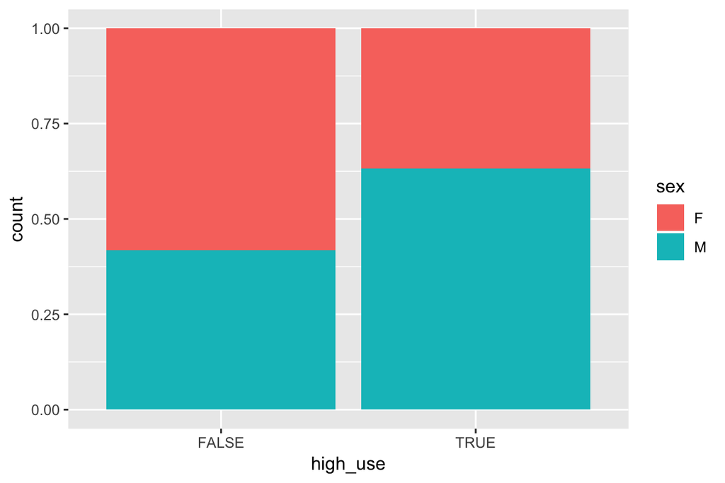

```r
library(ggplot2)
ggplot(alc, aes(x = high_use, fill = sex)) +
  geom_bar(position = "fill")
```

Majority of the students with high alcohol consumption were men.

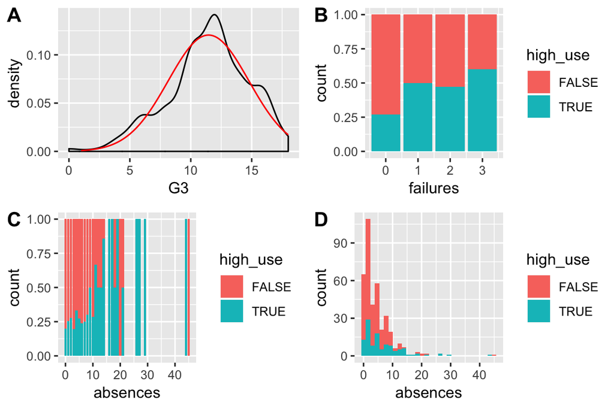

```r
library(ggpubr)
library(dplyr)
dens_score<- ggplot(alc, aes(x = G3)) +
geom_density()
x <- seq(1, 18, length.out=100)
df <- with(alc, data.frame(x = x, y = dnorm(x, mean(G3), sd(G3))))
dens_score2<-dens_score + geom_line(data = df, aes(x = x, y = y), color = "red")

dens_fail <- ggplot(alc, aes(x = failures, fill = high_use)) +
geom_bar(position="fill")

dens_abs <- ggplot(alc, aes(x = absences, fill = high_use)) +
geom_bar(position = "fill")

dens2_abs <- ggplot(alc, aes(x = absences, fill = high_use)) +
geom_histogram()

#  facet_wrap(~ high_use)
ggarrange(dens_score2, dens_fail, dens_abs, dens2_abs,
          labels = c("A", "B", "C", "D"),
          ncol = 2, nrow = 2)
```

From A we can see that the scores are somewhat, even if not completely, normally distributed.

B shows the number of failures as a ratio between students with high and low alcohol consumption. We can see that the share of students with high alcohol use grows, as the amount of failures grow. The findings support the hypothesis that with high alcohol consumption grows the risk of failure.

Also, in C the share of students with high alcohol consumption grows as the amount of absences grow. This supports the view that students with high alcohol consumption have more absences than the students with low alcohol consumption.

D is graph C in absolute values, where we can see that the mumber of absencees is diminishing. There are some outliers in the data.

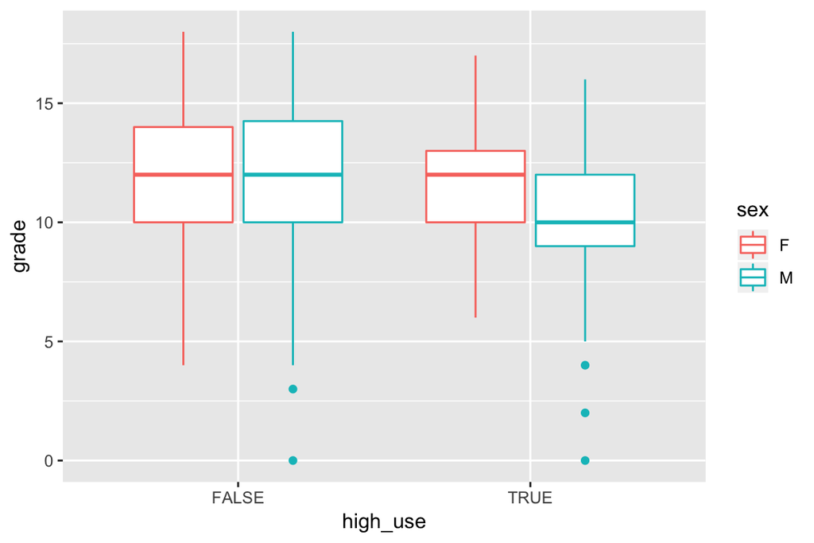

```r
library(ggplot2)

# initialize a plot of high_use and G3
g1 <- ggplot(alc, aes(x = high_use, y = G3, col = sex))

# define the plot as a boxplot and draw it
g1 + geom_boxplot() + ylab("grade")
```

Distribution of grades seem more symmetric among students with low alcohol consumption, and grades of both sexes have more spread than in the case of high consumption. Grades of men are clearly more affected by heavy consumption, than women’s, as the mean of grades for women is almost the same in both cases. For men, there are outliers who received bad grades and how much they drink does not seem to affect it.

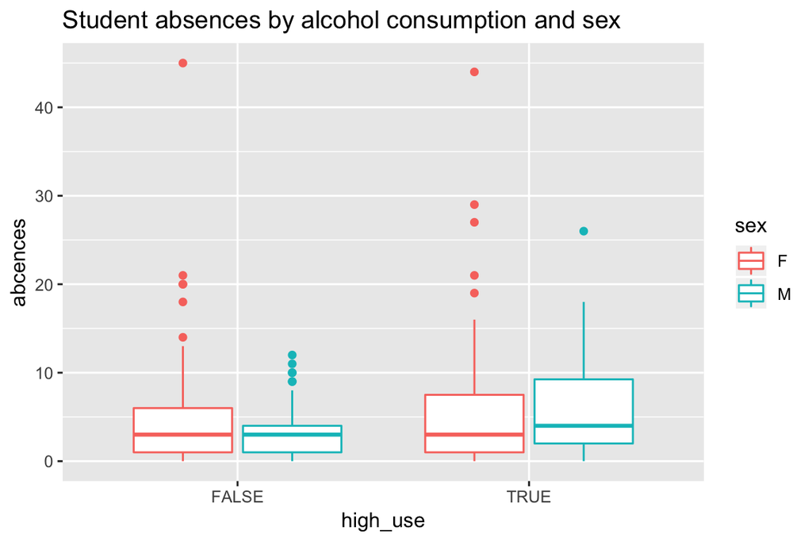

```r
# initialise a plot of high_use and absences
g2 <- ggplot(alc, aes(x = high_use, y = absences, col = sex))

# define the plot as a boxplot and draw it
g2 + geom_boxplot() + ylab("abcences") + ggtitle("Student absences by alcohol consumption and sex")
```

Absences seem to increase when alcohol consumption is high, which makes sense as high consumption has tendency to make you feel like crap the next morning. Again, we can see that absences of men are more affected by drinking. Women have more absences than men when consuming a little and there are pretty high amount of absences for the outliers in the women’s data.

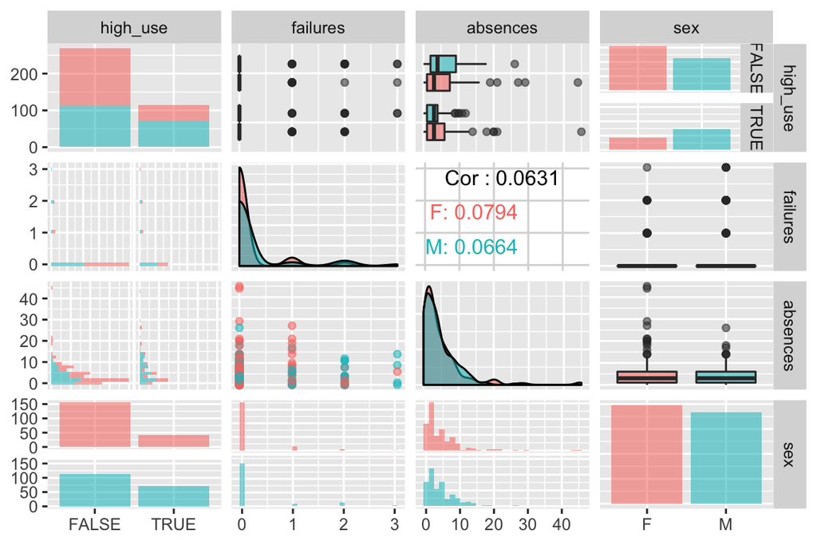

```r
library(GGally)
vars <- c("high_use","failures","absences","sex")
ggpairs(alc, columns = vars, mapping = aes(col = sex, alpha = 0.3), lower = list(combo = wrap("facethist")))
```

Last but not least, we can see that there’s not much correlation between *failures* and *absence*. There was about the same amount of both of the sexes in the data, even if there was slightly more women.

## 5 Interpreting the logistic regression

```r
# find the model with glm()
m <- glm(high_use ~ failures + absences + sex, data = alc, family = "binomial")
# print out a summary of the model
summary(m)
```

```
##
## Call:
## glm(formula = high_use ~ failures + absences + sex, family = "binomial",
##     data = alc)
##
## Deviance Residuals:
##     Min       1Q   Median       3Q      Max
## -2.1855  -0.8371  -0.6000   1.1020   2.0209
##
## Coefficients:
##             Estimate Std. Error z value Pr(>|z|)
## (Intercept) -1.90297    0.22626  -8.411  < 2e-16 ***
## failures     0.45082    0.18992   2.374 0.017611 *
## absences     0.09322    0.02295   4.063 4.85e-05 ***
## sexM         0.94117    0.24200   3.889 0.000101 ***
## ---
## Signif. codes:  0 '***' 0.001 '**' 0.01 '*' 0.05 '.' 0.1 ' ' 1
##
## (Dispersion parameter for binomial family taken to be 1)
##
##     Null deviance: 465.68  on 381  degrees of freedom
## Residual deviance: 424.40  on 378  degrees of freedom
## AIC: 432.4
##
## Number of Fisher Scoring iterations: 4
```

```r
#Round the coefficents for cleaner look
clean <- round(coef(m), digits=3)
print(clean)
```

```
## (Intercept)    failures    absences        sexM
##      -1.903       0.451       0.093       0.941
```

```r
mean(m$residuals)
```

```
## [1] 0.02143222
```

Here we can see the summary of the model. All explanatory variables are statistically significant at 95% confidence level. *Absences* and *sex* are significant even with 99.9%.

For every one unit change in *failures*, the log odds of *high_use* (versus low-use) increases by 0.451.  
For every one unit change in *absences*, the log odds of *high_use* (versus low-use) increases by 0.093.  
If the person in question is a male, the log odds of *high_use* increases by 0.941.

Therefore this fitted model says that, holding *failures* and *absences* at a fixed value, the odds of a high alcohol consumption for a male (*sex* = 1) over the odds of high alcohol consumption for female (*sex* = 0) is exp(0.941166) ≈ 2.563. In terms of percent change, we can say that the odds for men are 156% higher than the odds for women. The coefficient for *failures* says that, holding *absences* and *sex* at a fixed value, we will see 57% increase in the odds of having high alcohol consumption for a one-unit increase in failures since exp(0.4508198) ≈1.57. Variable *absences* has the same interpretation.

Residuals of the regression are close to mean zero, which is what we would want.

```r
# compute odds ratios (OR)
OR <- coef(m) %>% exp

# compute confidence intervals (CI)
CI <- confint(m) %>% exp

# print out the odds ratios with their confidence intervals
cbind(OR, CI)
```

```
##                    OR      2.5 %   97.5 %
## (Intercept) 0.1491257 0.09395441 0.228611
## failures    1.5695984 1.08339644 2.294737
## absences    1.0977032 1.05169654 1.150848
## sexM        2.5629682 1.60381392 4.149405
```

Here we can see the odds ratios for the variables and their corresponding confidence intervals. Note that for logistic models, confidence intervals are based on the profiled log-likelihood function.

Following is an excerpt from [here](http://www.sthda.com/english/articles/36-classification-methods-essentials/151-logistic-regression-essentials-in-r/#interpretation).

> An odds ratio measures the association between a predictor variable (x) and the outcome variable (y). It represents the ratio of the odds that an event will occur (event = 1) given the presence of the predictor x (x = 1), compared to the odds of the event occurring in the absence of that predictor (x = 0). For a given predictor (say x1), the associated beta coefficient (b1) in the logistic regression function corresponds to the log of the odds ratio for that predictor. If the odds ratio is 2, then the odds that the event occurs (event = 1) are two times higher when the predictor x is present (x = 1) versus x is absent (x = 0).

The confidence interval can be interpreted so that the true value of the coefficient belongs to this interval at 95% of the times. Confint function is showing two-tailed, from the 2.5% point to the 97.5% point of the relevant distribution, which form the upper and lower limits of the intervals.

Lets recap my intuition in the beginning of this analysis part:

- a high use of alcohol is likely related to absences and also failures.

Seems like failures and high use of alcohol are related. We can see this from the statistically significant coefficients of the regression.

- absences might be indicator of failures by itself, even without high alcohol consumption, as there can be multiple reasons for these absences.

Absences are also statistically significant, but presence of them does not raise the odds that much. There is probably many more reasons for being absent than alcohol intake.

- alcohol consumption habits might differ between men and women.

The data-analysis would seem to support the evidence, that it’s more likely that men have high alcohol consumption in the study group, and that they also get lower grades and are more absent with high alcohol consumption.

## 6 Exploring the predictive power of the chosen model

Target variable versus the predictions (2x2) tabulation

```r
# predict() the probability of high_use
probabilities <- predict(m, type = "response")

# add the predicted probabilities to 'alc'
alc <- mutate(alc, probability = probabilities)

# use the probabilities to make a prediction of high_use
alc <- mutate(alc, prediction = probability > 0.5)

# tabulate the target variable versus the predictions
table(high_use = alc$high_use, prediction = alc$prediction)
```

```
##         prediction
## high_use FALSE TRUE
##    FALSE   259    9
##    TRUE     84   30
```

We can see that the model predicted quite accurately when *high_use* was false, as we got only 9 predictions wrong out of 268.

However, it did not do so well when predicting when it’s true, as prediction was false 84 times out of 114. Graphical representation follows.

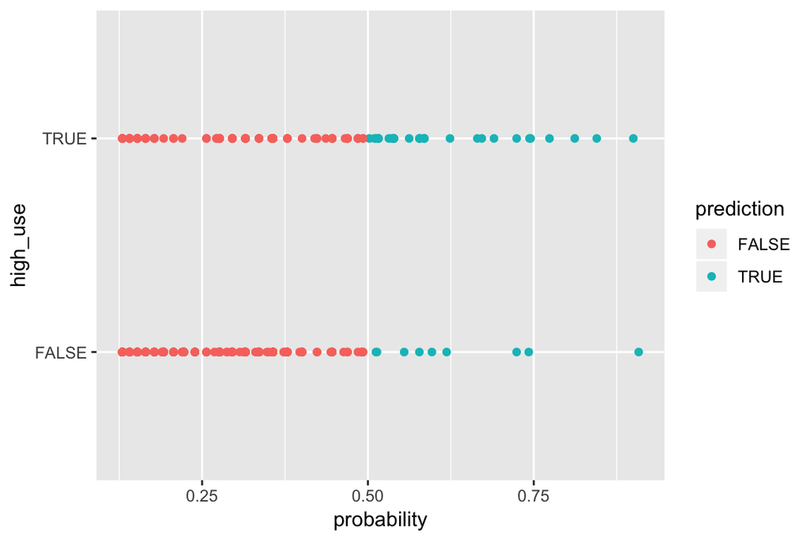

```r
# initialize a plot of 'high_use' versus 'probability' in 'alc'
g <- ggplot(alc, aes(x = probability, y = high_use, col=prediction))

# define the geom as points and draw the plot
g + geom_point()
```

```r
# tabulate the target variable versus the predictions
table(high_use = alc$high_use, prediction = alc$prediction) %>% prop.table() %>% addmargins()
```

```
##         prediction
## high_use      FALSE       TRUE        Sum
##    FALSE 0.67801047 0.02356021 0.70157068
##    TRUE  0.21989529 0.07853403 0.29842932
##    Sum   0.89790576 0.10209424 1.00000000
```

Computing the total proportion of inaccurately classified individuals (= the training error):

```r
# define a loss function (mean prediction error)
loss_func <- function(class, prob) {
  n_wrong <- abs(class - prob) > 0.5
  mean(n_wrong)
}

# call loss_func to compute the average number of wrong predictions in the (training) data
loss <- loss_func(class = alc$high_use, prob = alc$probability)
print(loss)
```

```
## [1] 0.2434555
```

On average, our model predicts the end result wrong approx. 24% of the predictions in the training data.

## 7 10-fold cross-validation on the model

```r
# K-fold cross-validation
library(boot)
cv <- cv.glm(data = alc, cost = loss_func, glmfit = m, K = 10)
# average number of wrong predictions in the cross validation
cv$delta[1]
```

```
## [1] 0.2539267
```

Average number of wrong predictions in the cross validation is approximately 0.25. My chosen model is exactly the same as in the datacamp exercise, so of course the prediction error is the same. When comparing different models, we would prefer a model with smaller penalty (i.e. error). If one could re-select the explanatory variables so that the error would be smaller, that model could be preferred in prediction over this one. If more variables are added to the regression, the average error grows.